# ISLR_Ch_8_HW

## Problem 9

This problem involves the [OJ](https://rdrr.io/cran/ISLR/man/OJ.html) data set which is part of the `ISLR` package.

```r
attach(OJ)
set.seed(40)
```

**(a)Create a training set containing a random sample of 800 observations, and a test set containing the remaining observations.**

```r
train <- sample(dim(OJ)[1], 800)
oj_train <- OJ[train,]
oj_test <- OJ[-train,]
```

**(b) Fit a tree to the training data with `Purchase` as the response and the other variables as predictors. Use the `summary()` function to produce summary statistics about the tree, and describe the results obtained. What is the training error rate? How many terminal nodes does the tree have?**

```r
oj_tree <- tree(Purchase ~ ., data = oj_train)
summary(oj_tree)
```

```
##
## Classification tree:
## tree(formula = Purchase ~ ., data = oj_train)
## Variables actually used in tree construction:
## [1] "LoyalCH"       "PriceDiff"     "ListPriceDiff"
## Number of terminal nodes:  6
## Residual mean deviance:  0.7886 = 626.1 / 794
## Misclassification error rate: 0.185 = 148 / 800
```

The training error rate is 0.185 (148/800). There are 6 terminal nodes and the three variables used are `LoyalCH`, `PriceDiff`, and `ListPriceDiff`.

**(c) Type in the name of the tree object in order to get a detailed text output. Pick one of the terminal nodes, and interpret the information displayed.**

```r
oj_tree
```

```
## node), split, n, deviance, yval, (yprob)
##       * denotes terminal node
##
##  1) root 800 1073.00 CH ( 0.60625 0.39375 )
##    2) LoyalCH < 0.483036 307  329.60 MM ( 0.22801 0.77199 )
##      4) LoyalCH < 0.0356415 63   10.27 MM ( 0.01587 0.98413 ) *
##      5) LoyalCH > 0.0356415 244  290.60 MM ( 0.28279 0.71721 )
##       10) PriceDiff < 0.31 192  204.20 MM ( 0.22396 0.77604 ) *
##       11) PriceDiff > 0.31 52   72.09 CH ( 0.50000 0.50000 ) *
##    3) LoyalCH > 0.483036 493  430.60 CH ( 0.84178 0.15822 )
##      6) LoyalCH < 0.753545 238  282.90 CH ( 0.71849 0.28151 )
##       12) ListPriceDiff < 0.235 93  128.90 CH ( 0.50538 0.49462 ) *
##       13) ListPriceDiff > 0.235 145  120.00 CH ( 0.85517 0.14483 ) *
##      7) LoyalCH > 0.753545 255   90.67 CH ( 0.95686 0.04314 ) *
```

For terminal node 11, PriceDiff, the splitting node is 0.31 and there are 52 points in this sub tree. The deviance is 72.09. The * at the end indicates that this is a terminal node. At this particular node, 50% of the sales are CH and 50% are MM.

**(d) Create a plot of the tree and interpret the results.**

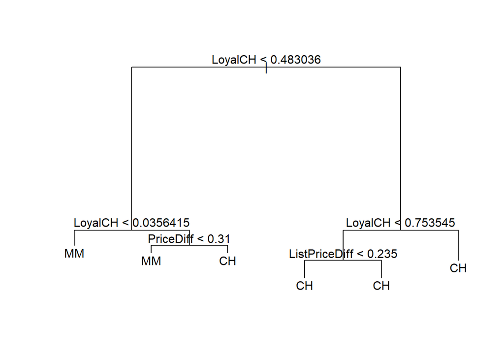

```r
plot(oj_tree)
text(oj_tree, pretty = 0)
```

**(e) Predict the response on the test data, and produce a confusion matrix comparing the test labels to the predicted test labels. What is the error rate?**

```r
oj_pred <- predict(oj_tree, oj_test, type = "class")
table(oj_test$Purchase, oj_pred)
```

```
##     oj_pred
##       CH  MM
##   CH 148  20
##   MM  34  68
```

```r
1-((148+68)/(148+20+34+68))
```

```
## [1] 0.2
```

The error rate is about 20%.

**(f) Apply the `cv.tree()` function to the training set in order to determine the optimal tree size.**

```r
cv_oj <- cv.tree(oj_tree, FUN = prune.tree)
cv_oj
```

```
## $size
## [1] 6 5 4 3 2 1
##
## $dev
## [1]  763.2776  726.6137  759.9587  776.2884  792.4920 1075.8966
##
## $k
## [1]      -Inf  14.30998  28.72806  34.05546  56.98859 312.41460
##
## $method
## [1] "deviance"
##
## attr(,"class")
## [1] "prune"         "tree.sequence"
```

**(g) Produce a plot with tree size on the $x$-axis and cross-validated classification error rate on the $y$-axis.**

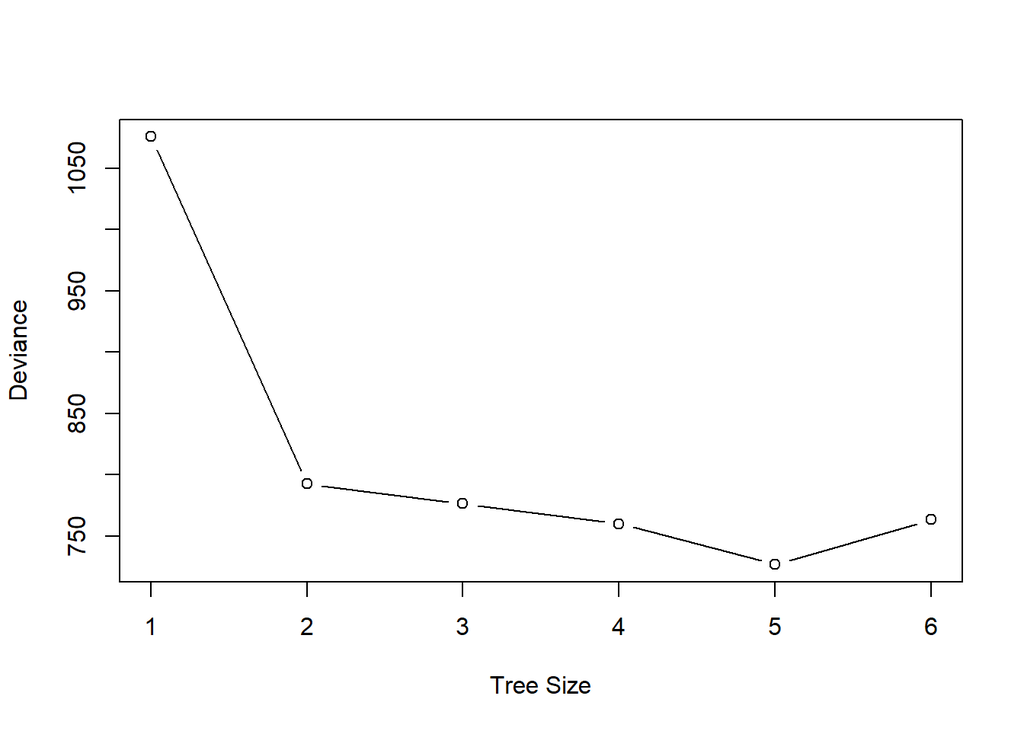

```r
plot(cv_oj$size, cv_oj$dev, type = "b", xlab = "Tree Size", ylab = "Deviance")
```

**(h) Which tree size corresponds to the lowest cross-validated classification error rate?**

A tree size of 5 gives the lowest cross-validation error rate.

**(i) Produce a pruned tree corresponding to the optimal tree size obtained using cross-validation. If cross-validation does not lead to selection of a pruned tree, then create a pruned tree with five terminal nodes.**

```r
oj_prune = prune.tree(oj_tree, best = 5)
```

**(j) Compare the training error rates between the pruned and unpruned trees. Which is higher?**

```r
summary(oj_tree)
```

```
##
## Classification tree:
## tree(formula = Purchase ~ ., data = oj_train)
## Variables actually used in tree construction:
## [1] "LoyalCH"       "PriceDiff"     "ListPriceDiff"
## Number of terminal nodes:  6
## Residual mean deviance:  0.7886 = 626.1 / 794
## Misclassification error rate: 0.185 = 148 / 800
```

```r
summary(oj_prune)
```

```
##
## Classification tree:
## snip.tree(tree = oj_tree, nodes = 5L)
## Variables actually used in tree construction:
## [1] "LoyalCH"       "ListPriceDiff"
## Number of terminal nodes:  5
## Residual mean deviance:  0.8056 = 640.4 / 795
## Misclassification error rate: 0.185 = 148 / 800
```

Both the pruned and unpruned trees have the same error rate of 18.5%.

**(k) Compare the test error rates between the pruned and unpruned tree. Which is higher?**

```r
tree_pred <- predict(oj_prune, newdata = oj_test, type = "class")
table(tree_pred, oj_test$Purchase)
```

```
##
## tree_pred  CH  MM
##        CH 144  32
##        MM  24  70
```

```r
 1-((144+70)/(144+32+24+70))
```

```
## [1] 0.2074074
```